# Risk Factor Analysis

## Outcome Variable

**Outcome Variable:** wasted

## Predictor Variables

**Intervention Variable:** hdlvry

**Adjustment Set:**

unadjusted

## Stratifying Variables

The analysis was stratified on these variable(s):

- agecat
- studyid
- country

## Data Summary

| agecat | studyid | country | hdlvry | wasted | n_cell | n |
| --- | --- | --- | --- | --- | --- | --- |
| Birth | CMC-V-BCS-2002 | INDIA | 0 | 0 | 75 | 86 |
| Birth | CMC-V-BCS-2002 | INDIA | 0 | 1 | 11 | 86 |
| Birth | CMC-V-BCS-2002 | INDIA | 1 | 0 | 0 | 86 |
| Birth | CMC-V-BCS-2002 | INDIA | 1 | 1 | 0 | 86 |
| Birth | COHORTS | INDIA | 0 | 0 | 2284 | 4389 |
| Birth | COHORTS | INDIA | 0 | 1 | 479 | 4389 |
| Birth | COHORTS | INDIA | 1 | 0 | 1344 | 4389 |
| Birth | COHORTS | INDIA | 1 | 1 | 282 | 4389 |
| Birth | EE | PAKISTAN | 0 | 0 | 106 | 175 |
| Birth | EE | PAKISTAN | 0 | 1 | 14 | 175 |
| Birth | EE | PAKISTAN | 1 | 0 | 47 | 175 |
| Birth | EE | PAKISTAN | 1 | 1 | 8 | 175 |
| Birth | GMS-Nepal | NEPAL | 0 | 0 | 109 | 596 |
| Birth | GMS-Nepal | NEPAL | 0 | 1 | 34 | 596 |
| Birth | GMS-Nepal | NEPAL | 1 | 0 | 364 | 596 |
| Birth | GMS-Nepal | NEPAL | 1 | 1 | 89 | 596 |
| Birth | IRC | INDIA | 0 | 0 | 249 | 343 |
| Birth | IRC | INDIA | 0 | 1 | 88 | 343 |
| Birth | IRC | INDIA | 1 | 0 | 2 | 343 |
| Birth | IRC | INDIA | 1 | 1 | 4 | 343 |
| Birth | NIH-Crypto | BANGLADESH | 0 | 0 | 426 | 707 |
| Birth | NIH-Crypto | BANGLADESH | 0 | 1 | 122 | 707 |
| Birth | NIH-Crypto | BANGLADESH | 1 | 0 | 109 | 707 |
| Birth | NIH-Crypto | BANGLADESH | 1 | 1 | 50 | 707 |
| Birth | PROVIDE | BANGLADESH | 0 | 0 | 303 | 532 |
| Birth | PROVIDE | BANGLADESH | 0 | 1 | 84 | 532 |
| Birth | PROVIDE | BANGLADESH | 1 | 0 | 112 | 532 |
| Birth | PROVIDE | BANGLADESH | 1 | 1 | 33 | 532 |
| Birth | SAS-CompFeed | INDIA | 0 | 0 | 98 | 957 |
| Birth | SAS-CompFeed | INDIA | 0 | 1 | 10 | 957 |

[output cut: 74 more lines]

The following strata were considered:

- agecat: 24 months, studyid: CMC-V-BCS-2002, country: INDIA
- agecat: 24 months, studyid: COHORTS, country: INDIA
- agecat: 24 months, studyid: EE, country: PAKISTAN
- agecat: 24 months, studyid: GMS-Nepal, country: NEPAL
- agecat: 24 months, studyid: IRC, country: INDIA
- agecat: 24 months, studyid: NIH-Crypto, country: BANGLADESH
- agecat: 24 months, studyid: PROVIDE, country: BANGLADESH
- agecat: 24 months, studyid: TanzaniaChild2, country: TANZANIA, UNITED REPUBLIC OF
- agecat: 6 months, studyid: CMC-V-BCS-2002, country: INDIA
- agecat: 6 months, studyid: COHORTS, country: INDIA
- agecat: 6 months, studyid: EE, country: PAKISTAN
- agecat: 6 months, studyid: GMS-Nepal, country: NEPAL
- agecat: 6 months, studyid: IRC, country: INDIA
- agecat: 6 months, studyid: NIH-Crypto, country: BANGLADESH
- agecat: 6 months, studyid: PROVIDE, country: BANGLADESH
- agecat: 6 months, studyid: SAS-CompFeed, country: INDIA
- agecat: 6 months, studyid: SAS-FoodSuppl, country: INDIA
- agecat: 6 months, studyid: TanzaniaChild2, country: TANZANIA, UNITED REPUBLIC OF
- agecat: Birth, studyid: CMC-V-BCS-2002, country: INDIA
- agecat: Birth, studyid: COHORTS, country: INDIA
- agecat: Birth, studyid: EE, country: PAKISTAN
- agecat: Birth, studyid: GMS-Nepal, country: NEPAL
- agecat: Birth, studyid: IRC, country: INDIA
- agecat: Birth, studyid: NIH-Crypto, country: BANGLADESH
- agecat: Birth, studyid: PROVIDE, country: BANGLADESH
- agecat: Birth, studyid: SAS-CompFeed, country: INDIA

### Dropped Strata

Some strata were dropped due to rare outcomes:

- agecat: Birth, studyid: CMC-V-BCS-2002, country: INDIA
- agecat: Birth, studyid: IRC, country: INDIA
- agecat: 6 months, studyid: CMC-V-BCS-2002, country: INDIA
- agecat: 6 months, studyid: IRC, country: INDIA
- agecat: 6 months, studyid: PROVIDE, country: BANGLADESH
- agecat: 6 months, studyid: TanzaniaChild2, country: TANZANIA, UNITED REPUBLIC OF
- agecat: 24 months, studyid: CMC-V-BCS-2002, country: INDIA
- agecat: 24 months, studyid: IRC, country: INDIA
- agecat: 24 months, studyid: TanzaniaChild2, country: TANZANIA, UNITED REPUBLIC OF

## Methods Detail

We’re interested in the causal parameters $E[Y_a]$ for all values of $a \in \mathcal{A}$. These parameters represent the mean outcome if, possibly contrary to fact, we intervened to set all units to have $A=a$. Under the randomization and positivity assumptions, these are identified by the statistical parameters $\psi_a=E_W[E_{Y|A,W}(Y|A=a,W)]$. In addition, we’re interested in the mean of $Y$, $E[Y]$ under no intervention (the observed mean). We will estimate these parameters by using SuperLearner to fit the relevant likelihood factors – $E_{Y|A,W}(Y|A=a,W)$ and $p(A=a|W)$, and then updating our likelihood fit using a joint TMLE.

For unadjusted analyses ($W=\{\}$), initial likelihoods were estimated using Lrnr_glm to estimate the simple $E(Y|A)$ and Lrnr_mean to estimate $p(A)$. For adjusted analyses, a small library containing Lrnr_glmnet, Lrnr_xgboost, and Lrnr_mean was used.

Having estimated these parameters, we will then use the delta method to estimate relative risks and attributable risks relative to a prespecified baseline level of $A$.

# Results Detail

## Results Plots

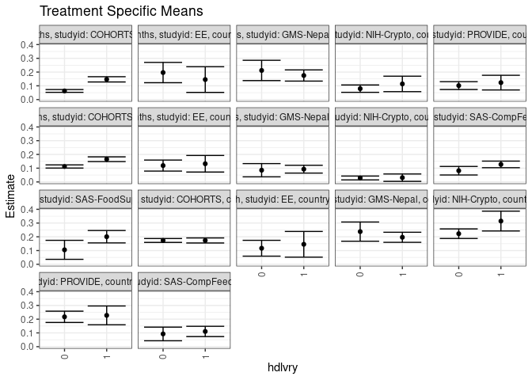

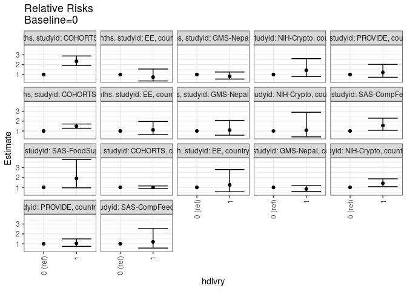

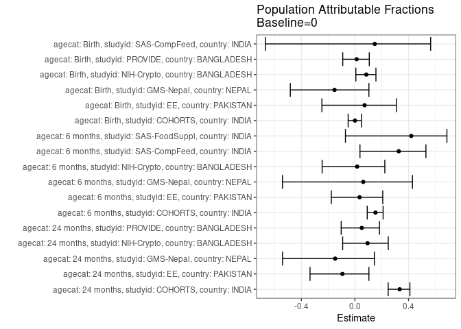

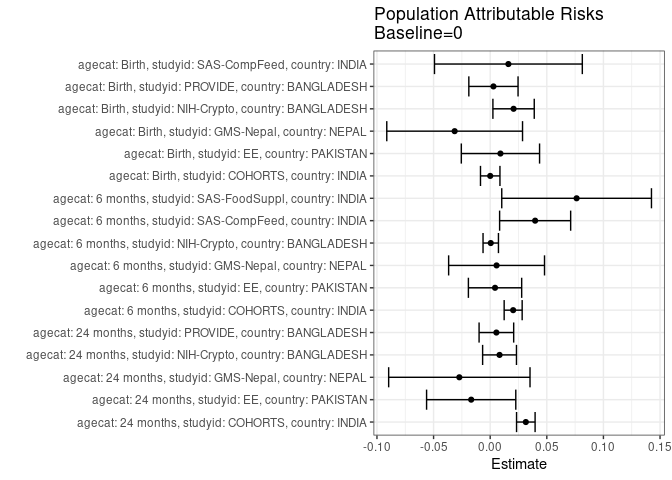

## Results Table

### Parameter: TSM

| agecat | studyid | country | intervention_level | baseline_level | estimate | ci_lower | ci_upper |
| --- | --- | --- | --- | --- | --- | --- | --- |
| Birth | COHORTS | INDIA | 0 | NA | 0.1733623 | 0.1592453 | 0.1874793 |
| Birth | COHORTS | INDIA | 1 | NA | 0.1734317 | 0.1550265 | 0.1918370 |
| Birth | EE | PAKISTAN | 0 | NA | 0.1166667 | 0.0590647 | 0.1742687 |
| Birth | EE | PAKISTAN | 1 | NA | 0.1454545 | 0.0520125 | 0.2388966 |
| Birth | GMS-Nepal | NEPAL | 0 | NA | 0.2377622 | 0.1679291 | 0.3075953 |
| Birth | GMS-Nepal | NEPAL | 1 | NA | 0.1964680 | 0.1598486 | 0.2330874 |
| Birth | NIH-Crypto | BANGLADESH | 0 | NA | 0.2226277 | 0.1877724 | 0.2574831 |
| Birth | NIH-Crypto | BANGLADESH | 1 | NA | 0.3144654 | 0.2422453 | 0.3866855 |
| Birth | PROVIDE | BANGLADESH | 0 | NA | 0.2170543 | 0.1759439 | 0.2581646 |
| Birth | PROVIDE | BANGLADESH | 1 | NA | 0.2275862 | 0.1592784 | 0.2958941 |
| Birth | SAS-CompFeed | INDIA | 0 | NA | 0.0925926 | 0.0429905 | 0.1421947 |
| Birth | SAS-CompFeed | INDIA | 1 | NA | 0.1107185 | 0.0734203 | 0.1480166 |
| 6 months | COHORTS | INDIA | 0 | NA | 0.1122238 | 0.1007266 | 0.1237209 |
| 6 months | COHORTS | INDIA | 1 | NA | 0.1651835 | 0.1480172 | 0.1823499 |
| 6 months | EE | PAKISTAN | 0 | NA | 0.1190476 | 0.0790101 | 0.1590852 |
| 6 months | EE | PAKISTAN | 1 | NA | 0.1322314 | 0.0717937 | 0.1926691 |
| 6 months | GMS-Nepal | NEPAL | 0 | NA | 0.0852713 | 0.0370307 | 0.1335119 |
| 6 months | GMS-Nepal | NEPAL | 1 | NA | 0.0927318 | 0.0642443 | 0.1212194 |
| 6 months | NIH-Crypto | BANGLADESH | 0 | NA | 0.0288809 | 0.0149256 | 0.0428361 |
| 6 months | NIH-Crypto | BANGLADESH | 1 | NA | 0.0310559 | 0.0042420 | 0.0578698 |
| 6 months | SAS-CompFeed | INDIA | 0 | NA | 0.0816327 | 0.0505071 | 0.1127582 |
| 6 months | SAS-CompFeed | INDIA | 1 | NA | 0.1275239 | 0.1035834 | 0.1514644 |
| 6 months | SAS-FoodSuppl | INDIA | 0 | NA | 0.1052632 | 0.0361757 | 0.1743506 |
| 6 months | SAS-FoodSuppl | INDIA | 1 | NA | 0.2006579 | 0.1555785 | 0.2457373 |
| 24 months | COHORTS | INDIA | 0 | NA | 0.0627823 | 0.0526768 | 0.0728878 |
| 24 months | COHORTS | INDIA | 1 | NA | 0.1470811 | 0.1279641 | 0.1661981 |
| 24 months | EE | PAKISTAN | 0 | NA | 0.1964286 | 0.1226283 | 0.2702288 |
| 24 months | EE | PAKISTAN | 1 | NA | 0.1454545 | 0.0519996 | 0.2389095 |
| 24 months | GMS-Nepal | NEPAL | 0 | NA | 0.2118644 | 0.1380546 | 0.2856743 |
| 24 months | GMS-Nepal | NEPAL | 1 | NA | 0.1750742 | 0.1344552 | 0.2156932 |
| 24 months | NIH-Crypto | BANGLADESH | 0 | NA | 0.0792839 | 0.0524775 | 0.1060903 |
| 24 months | NIH-Crypto | BANGLADESH | 1 | NA | 0.1138211 | 0.0576400 | 0.1700023 |
| 24 months | PROVIDE | BANGLADESH | 0 | NA | 0.1016166 | 0.0731332 | 0.1301001 |
| 24 months | PROVIDE | BANGLADESH | 1 | NA | 0.1232877 | 0.0699130 | 0.1766624 |

### Parameter: E(Y)

| agecat | studyid | country | intervention_level | baseline_level | estimate | ci_lower | ci_upper |
| --- | --- | --- | --- | --- | --- | --- | --- |
| Birth | COHORTS | INDIA | NA | NA | 0.1733880 | 0.1621865 | 0.1845895 |
| Birth | EE | PAKISTAN | NA | NA | 0.1257143 | 0.0764545 | 0.1749741 |
| Birth | GMS-Nepal | NEPAL | NA | NA | 0.2063758 | 0.1738576 | 0.2388940 |
| Birth | NIH-Crypto | BANGLADESH | NA | NA | 0.2432815 | 0.2116319 | 0.2749310 |
| Birth | PROVIDE | BANGLADESH | NA | NA | 0.2199248 | 0.1846953 | 0.2551543 |
| Birth | SAS-CompFeed | INDIA | NA | NA | 0.1086729 | 0.0774328 | 0.1399131 |
| 6 months | COHORTS | INDIA | NA | NA | 0.1325096 | 0.1228094 | 0.1422097 |
| 6 months | EE | PAKISTAN | NA | NA | 0.1233244 | 0.0899110 | 0.1567378 |
| 6 months | GMS-Nepal | NEPAL | NA | NA | 0.0909091 | 0.0663648 | 0.1154534 |
| 6 months | NIH-Crypto | BANGLADESH | NA | NA | 0.0293706 | 0.0169860 | 0.0417552 |
| 6 months | SAS-CompFeed | INDIA | NA | NA | 0.1213235 | 0.0974115 | 0.1452356 |
| 6 months | SAS-FoodSuppl | INDIA | NA | NA | 0.1815789 | 0.1427684 | 0.2203895 |
| 24 months | COHORTS | INDIA | NA | NA | 0.0942542 | 0.0846183 | 0.1038901 |
| 24 months | EE | PAKISTAN | NA | NA | 0.1796407 | 0.1212426 | 0.2380388 |
| 24 months | GMS-Nepal | NEPAL | NA | NA | 0.1846154 | 0.1489263 | 0.2203045 |
| 24 months | NIH-Crypto | BANGLADESH | NA | NA | 0.0875486 | 0.0630907 | 0.1120065 |
| 24 months | PROVIDE | BANGLADESH | NA | NA | 0.1070812 | 0.0818727 | 0.1322897 |

### Parameter: RR

| agecat | studyid | country | intervention_level | baseline_level | estimate | ci_lower | ci_upper |
| --- | --- | --- | --- | --- | --- | --- | --- |
| Birth | COHORTS | INDIA | 0 | 0 | 1.0000000 | 1.0000000 | 1.000000 |
| Birth | COHORTS | INDIA | 1 | 0 | 1.0004006 | 0.8751457 | 1.143582 |
| Birth | EE | PAKISTAN | 0 | 0 | 1.0000000 | 1.0000000 | 1.000000 |
| Birth | EE | PAKISTAN | 1 | 0 | 1.2467532 | 0.5545027 | 2.803221 |
| Birth | GMS-Nepal | NEPAL | 0 | 0 | 1.0000000 | 1.0000000 | 1.000000 |
| Birth | GMS-Nepal | NEPAL | 1 | 0 | 0.8263213 | 0.5835465 | 1.170098 |
| Birth | NIH-Crypto | BANGLADESH | 0 | 0 | 1.0000000 | 1.0000000 | 1.000000 |
| Birth | NIH-Crypto | BANGLADESH | 1 | 0 | 1.4125168 | 1.0697488 | 1.865114 |
| Birth | PROVIDE | BANGLADESH | 0 | 0 | 1.0000000 | 1.0000000 | 1.000000 |
| Birth | PROVIDE | BANGLADESH | 1 | 0 | 1.0485222 | 0.7352661 | 1.495239 |
| Birth | SAS-CompFeed | INDIA | 0 | 0 | 1.0000000 | 1.0000000 | 1.000000 |
| Birth | SAS-CompFeed | INDIA | 1 | 0 | 1.1957597 | 0.5643158 | 2.533761 |
| 6 months | COHORTS | INDIA | 0 | 0 | 1.0000000 | 1.0000000 | 1.000000 |
| 6 months | COHORTS | INDIA | 1 | 0 | 1.4719124 | 1.2720532 | 1.703172 |
| 6 months | EE | PAKISTAN | 0 | 0 | 1.0000000 | 1.0000000 | 1.000000 |
| 6 months | EE | PAKISTAN | 1 | 0 | 1.1107438 | 0.6297510 | 1.959110 |
| 6 months | GMS-Nepal | NEPAL | 0 | 0 | 1.0000000 | 1.0000000 | 1.000000 |
| 6 months | GMS-Nepal | NEPAL | 1 | 0 | 1.0874915 | 0.5712748 | 2.070173 |
| 6 months | NIH-Crypto | BANGLADESH | 0 | 0 | 1.0000000 | 1.0000000 | 1.000000 |
| 6 months | NIH-Crypto | BANGLADESH | 1 | 0 | 1.0753106 | 0.3997909 | 2.892244 |
| 6 months | SAS-CompFeed | INDIA | 0 | 0 | 1.0000000 | 1.0000000 | 1.000000 |
| 6 months | SAS-CompFeed | INDIA | 1 | 0 | 1.5621679 | 1.0634896 | 2.294680 |
| 6 months | SAS-FoodSuppl | INDIA | 0 | 0 | 1.0000000 | 1.0000000 | 1.000000 |
| 6 months | SAS-FoodSuppl | INDIA | 1 | 0 | 1.9062500 | 0.9525832 | 3.814668 |
| 24 months | COHORTS | INDIA | 0 | 0 | 1.0000000 | 1.0000000 | 1.000000 |
| 24 months | COHORTS | INDIA | 1 | 0 | 2.3427166 | 1.9048892 | 2.881176 |
| 24 months | EE | PAKISTAN | 0 | 0 | 1.0000000 | 1.0000000 | 1.000000 |
| 24 months | EE | PAKISTAN | 1 | 0 | 0.7404959 | 0.3517884 | 1.558704 |
| 24 months | GMS-Nepal | NEPAL | 0 | 0 | 1.0000000 | 1.0000000 | 1.000000 |
| 24 months | GMS-Nepal | NEPAL | 1 | 0 | 0.8263501 | 0.5437288 | 1.255873 |
| 24 months | NIH-Crypto | BANGLADESH | 0 | 0 | 1.0000000 | 1.0000000 | 1.000000 |
| 24 months | NIH-Crypto | BANGLADESH | 1 | 0 | 1.4356150 | 0.7892324 | 2.611386 |
| 24 months | PROVIDE | BANGLADESH | 0 | 0 | 1.0000000 | 1.0000000 | 1.000000 |
| 24 months | PROVIDE | BANGLADESH | 1 | 0 | 1.2132628 | 0.7243828 | 2.032084 |

### Parameter: PAR

| agecat | studyid | country | intervention_level | baseline_level | estimate | ci_lower | ci_upper |
| --- | --- | --- | --- | --- | --- | --- | --- |
| Birth | COHORTS | INDIA | 0 | NA | 0.0000257 | -0.0085676 | 0.0086191 |
| Birth | EE | PAKISTAN | 0 | NA | 0.0090476 | -0.0255086 | 0.0436038 |
| Birth | GMS-Nepal | NEPAL | 0 | NA | -0.0313864 | -0.0913360 | 0.0285632 |
| Birth | NIH-Crypto | BANGLADESH | 0 | NA | 0.0206537 | 0.0023988 | 0.0389087 |
| Birth | PROVIDE | BANGLADESH | 0 | NA | 0.0028705 | -0.0188626 | 0.0246037 |
| Birth | SAS-CompFeed | INDIA | 0 | NA | 0.0160803 | -0.0491955 | 0.0813562 |
| 6 months | COHORTS | INDIA | 0 | NA | 0.0202858 | 0.0123377 | 0.0282340 |
| 6 months | EE | PAKISTAN | 0 | NA | 0.0042768 | -0.0192492 | 0.0278027 |
| 6 months | GMS-Nepal | NEPAL | 0 | NA | 0.0056378 | -0.0366995 | 0.0479750 |
| 6 months | NIH-Crypto | BANGLADESH | 0 | NA | 0.0004898 | -0.0063172 | 0.0072967 |
| 6 months | SAS-CompFeed | INDIA | 0 | NA | 0.0396909 | 0.0083211 | 0.0710606 |
| 6 months | SAS-FoodSuppl | INDIA | 0 | NA | 0.0763158 | 0.0102090 | 0.1424226 |
| 24 months | COHORTS | INDIA | 0 | NA | 0.0314719 | 0.0232878 | 0.0396560 |
| 24 months | EE | PAKISTAN | 0 | NA | -0.0167879 | -0.0561751 | 0.0225994 |
| 24 months | GMS-Nepal | NEPAL | 0 | NA | -0.0272490 | -0.0896660 | 0.0351680 |
| 24 months | NIH-Crypto | BANGLADESH | 0 | NA | 0.0082648 | -0.0066858 | 0.0232153 |
| 24 months | PROVIDE | BANGLADESH | 0 | NA | 0.0054645 | -0.0098102 | 0.0207393 |

### Parameter: PAF

| agecat | studyid | country | intervention_level | baseline_level | estimate | ci_lower | ci_upper |
| --- | --- | --- | --- | --- | --- | --- | --- |
| Birth | COHORTS | INDIA | 0 | NA | 0.0001484 | -0.0506619 | 0.0485015 |
| Birth | EE | PAKISTAN | 0 | NA | 0.0719697 | -0.2465253 | 0.3090873 |
| Birth | GMS-Nepal | NEPAL | 0 | NA | -0.1520837 | -0.4819651 | 0.1043670 |
| Birth | NIH-Crypto | BANGLADESH | 0 | NA | 0.0848965 | 0.0070617 | 0.1566299 |
| Birth | PROVIDE | BANGLADESH | 0 | NA | 0.0130524 | -0.0908742 | 0.1070780 |
| Birth | SAS-CompFeed | INDIA | 0 | NA | 0.1479701 | -0.6683815 | 0.5648747 |
| 6 months | COHORTS | INDIA | 0 | NA | 0.1530895 | 0.0917707 | 0.2102684 |
| 6 months | EE | PAKISTAN | 0 | NA | 0.0346791 | -0.1760348 | 0.2076387 |
| 6 months | GMS-Nepal | NEPAL | 0 | NA | 0.0620155 | -0.5406708 | 0.4289403 |
| 6 months | NIH-Crypto | BANGLADESH | 0 | NA | 0.0166753 | -0.2445475 | 0.2230690 |
| 6 months | SAS-CompFeed | INDIA | 0 | NA | 0.3271490 | 0.0376845 | 0.5295426 |
| 6 months | SAS-FoodSuppl | INDIA | 0 | NA | 0.4202899 | -0.0708179 | 0.6861615 |
| 24 months | COHORTS | INDIA | 0 | NA | 0.3339044 | 0.2479494 | 0.4100352 |
| 24 months | EE | PAKISTAN | 0 | NA | -0.0934524 | -0.3348934 | 0.1043194 |
| 24 months | GMS-Nepal | NEPAL | 0 | NA | -0.1475989 | -0.5399897 | 0.1448104 |
| 24 months | NIH-Crypto | BANGLADESH | 0 | NA | 0.0944018 | -0.0914896 | 0.2486341 |
| 24 months | PROVIDE | BANGLADESH | 0 | NA | 0.0510318 | -0.1024387 | 0.1831377 |